# Homework 3

RMI 4226 Risk and Insurance Data Analytics – Fall 2025

**Objective:** This assignment aims to enhance your skills in data manipulation, specifically in reshaping data between long and wide formats, and in creating effective visualizations using `ggplot2`. By completing this exercise, you will learn to prepare data to answer specific questions and use appropriate graphs to communicate your findings.

**Dataset:** We will be working with a dataset containing information about insurance company assets stored in “naic_asset.rta”. This dataset includes the following variables: `COCODE` (company code), `COMPANY_NAME`, `COMPANY_TYPE_DESC` (company type), `CURRENT_YEAR` (asset value), `YEAR` (reporting year), and `LINE` (line of business). The `LINE` variable includes “Bonds”, “CashHandDeposit”, “Stocks_Com”, and “Total”.

**Data Preparation and Reshaping:**

1. **Data Loading and Filtering:**
   - Load the `naic_asset.rta` dataset.
   - Select the following columns: `COCODE`, `COMPANY_NAME`, `COMPANY_TYPE_DESC`, z`CURRENT_YEAR`, `YEAR`, and `LINE`.
   - Filter the data to retain only the rows where the `LINE` variable is either “Bonds”, “CashHandDeposit”, “Stocks_Com”, or “Total”.
   - Store the resulting data frame as `longdata`.

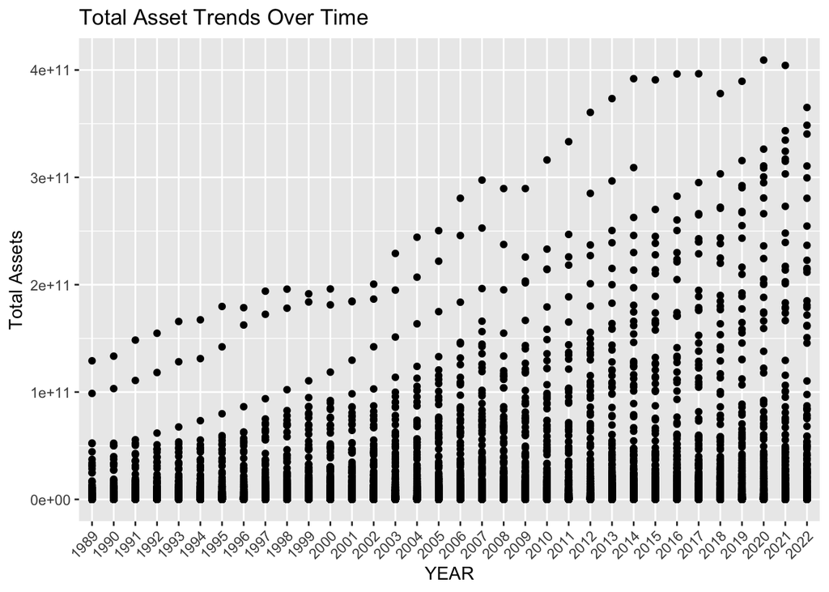

```r
rm(list = ls())
library(tidyverse)
load("naic_asset.rta")
temp <- MyData |> select(COCODE, COMPANY_NAME, COMPANY_TYPE_DESC, CURRENT_YEAR, YEAR, LINE)
longdata <- temp |>
  filter(LINE%in%c("Bonds", "CashHandDeposit", "Stocks_Com", "Total"))


widedata <- longdata %>%
  pivot_wider(
    names_from = LINE,
    values_from = CURRENT_YEAR
  ) %>%
  filter(Total > 0)

widedata <- widedata %>%
  mutate(
    bondRatio = Bonds / Total,
    stockRatio = Stocks_Com / Total,
    YEAR = as.factor(YEAR),
    COMPANY_TYPE_DESC = as.factor(COMPANY_TYPE_DESC)
  )

longdata <- widedata %>%
  pivot_longer(
    cols = c(Bonds, CashHandDeposit, Stocks_Com, Total, bondRatio, stockRatio),
    names_to = "name",
    values_to = "value"
  )

# Part 2

plot1 <- longdata %>%
  filter(name == "Total") %>%
  ggplot(aes(x = YEAR, y = value)) +
  geom_point() +
  theme(axis.text.x = element_text(angle = 45, hjust = 1)) + labs(title = "Total Asset Trends Over Time", y = "Total Assets")

print(plot1)
```

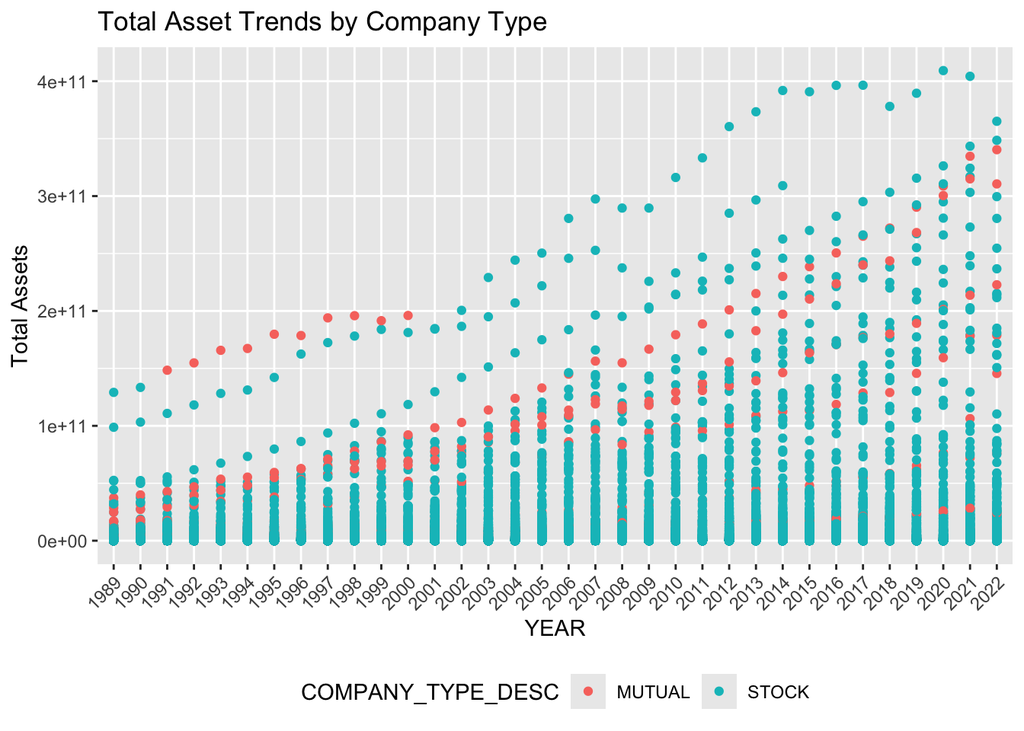

```r
plot2 <- longdata %>%
  filter(name == "Total") %>%
  ggplot(aes(x = YEAR, y = value, color = COMPANY_TYPE_DESC)) +
  geom_point() +
  theme(
    axis.text.x = element_text(angle = 45, hjust = 1),
    legend.position = "bottom"
  ) +
  labs(title = "Total Asset Trends by Company Type", y = "Total Assets")

print(plot2)
```

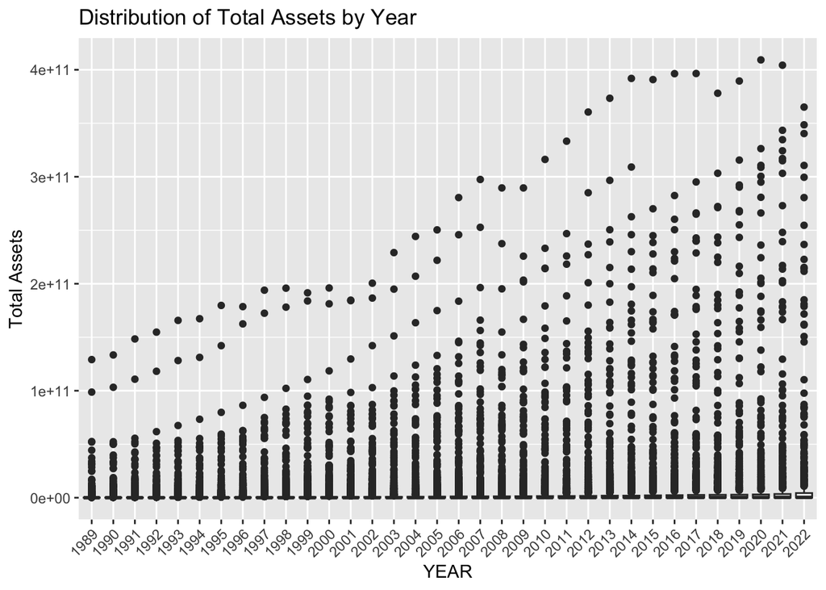

```r
plot3 <- longdata %>%
  filter(name == "Total") %>%
  ggplot(aes(x = YEAR, y = value)) +
  geom_boxplot() +
  theme(axis.text.x = element_text(angle = 45, hjust = 1)) +
  labs(title = "Distribution of Total Assets by Year", y = "Total Assets")

print(plot3)
```

[figure not shown]

```r
plot4 <- plot3 +
  ylim(0, 108) +
  labs(title = "Distribution of Total Assets (Zoomed 0-108)")

print(plot4)
```

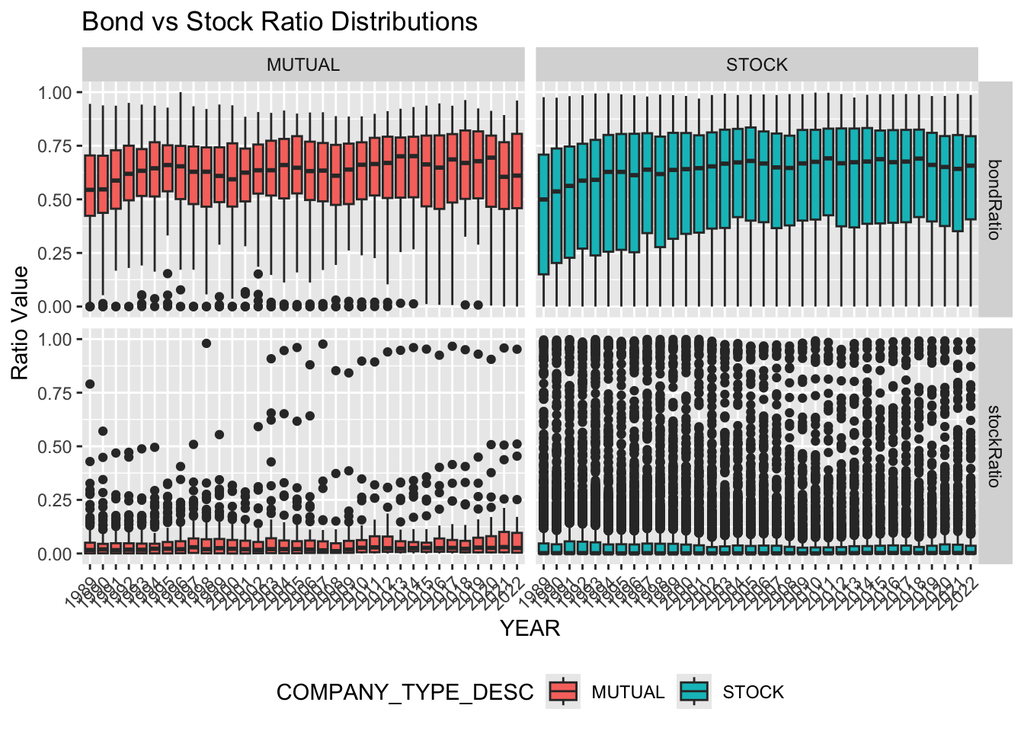

```r
plot5 <- longdata %>%
  filter(name == "bondRatio") %>%
  ggplot(aes(x = YEAR, y = value, fill = COMPANY_TYPE_DESC)) +
  geom_boxplot() +
  ylim(0, 1) +
  theme(
    axis.text.x = element_text(angle = 45, hjust = 1),
    legend.position = "bottom"
  ) +
  labs(title = "Bond Ratio Distribution by Company Type", y = "Bond Ratio")

plot6 <- longdata %>%
  filter(name %in% c("bondRatio", "stockRatio")) %>%
  ggplot(aes(x = YEAR, y = value, fill = COMPANY_TYPE_DESC)) +
  geom_boxplot() +
  ylim(0, 1) +
  facet_grid(name ~ COMPANY_TYPE_DESC) + # Facet by Ratio Name and Company Type
  theme(
    axis.text.x = element_text(angle = 45, hjust = 1),
    legend.position = "bottom"
  ) +
  labs(title = "Bond vs Stock Ratio Distributions", y = "Ratio Value")
print(plot6)
```

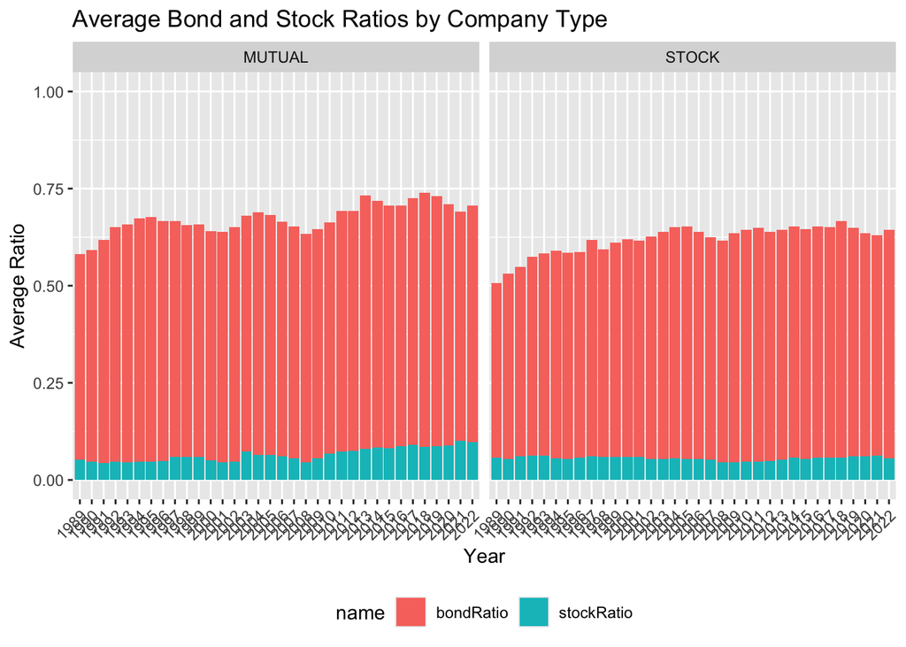

```r
plot7_data <- longdata %>%
  filter(name %in% c("bondRatio", "stockRatio")) %>%
  # Pivot to wide to calculate means easily
  pivot_wider(names_from = name, values_from = value) %>%
  group_by(YEAR, COMPANY_TYPE_DESC) %>%
  summarize(
    bondRatio = mean(bondRatio, na.rm = TRUE),
    stockRatio = mean(stockRatio, na.rm = TRUE),
    .groups = 'drop'
  ) %>%
  # Pivot back to long for plotting
  pivot_longer(
    cols = c(bondRatio, stockRatio),
    names_to = "name",
    values_to = "value"
  )
plot7 <- plot7_data %>%
  ggplot(aes(x = YEAR, y = value, fill = name)) +
  geom_bar(stat = "identity", position = "stack") +
  facet_wrap(~ COMPANY_TYPE_DESC) +
  ylim(0, 1) +
  theme(
    axis.text.x = element_text(angle = 45, hjust = 1),
    legend.position = "bottom"
  ) +
  labs(
    title = "Average Bond and Stock Ratios by Company Type",
    x = "Year",
    y = "Average Ratio"
  )

print(plot7)
```

2. **Pivoting to Wide Format:**
   - Transform the `longdata` from its current long format to a wide format.
   - Use the unique values in the `LINE` column (“Bonds”, “CashHandDeposit”, “Stocks_Com”, “Total”) as the names of the new columns (i.e., “Bonds”, “CashHandDeposit”, “Stocks_Com”, and “Total”).
   - Populate these new columns with the values from the `CURRENT_YEAR` column.
   - Retain all the other columns `COCODE`, `COMPANY_NAME`, `COMPANY_TYPE_DESC`, and `YEAR`.
   - Make sure all observations have a positive (non-zero) total assets (`Total`).
   - Store the resulting data frame as `widedata`.
3. **Creating Ratio Variables and Converting Data Types:**
   - Within `widedata`, calculate two new variables:
     - `bondRatio`: Compute this by dividing the values in the `Bonds` column by the corresponding values in the `Total` column.
     - `stockRatio`: Compute this by dividing the values in the `Stocks_Com` column by the corresponding values in the `Total` column.
   - Convert both the `YEAR` and `COMPANY_TYPE_DESC` columns into factors.
4. **Pivoting back to Long Format:**
   - Transform the `widedata` back to a long format.
   - Combine all columns except `COCODE`, `YEAR`, `COMPANY_NAME`, and `COMPANY_TYPE_DESC` into two columns: a `name` column and a `value` column.
   - The `name` column should contain the original column names that were transformed (`Bonds`, `CashHandDeposit`, `Stocks_Com`, `Total`, `bondRatio`, `stockRatio`), and the `value` column should contain the corresponding values.
   - Store this reshaped data as `longdata`.

**Data Visualization:**

5. **Visualizing Total Asset Trends Over Time:**
   - Create a point chart visualizing the trend of total assets (`value`) over the years (`YEAR`).
   - Filter the `longdata` to include only the rows where `name` is equal to “Total”.
   - Tilt the x-axis labels by 45 degrees for better readability.
6. **Comparing Total Asset Trends by Company Type:**
   - Enhance the point chart from the previous step by adding color to differentiate the trend of total assets across different company types (`COMPANY_TYPE_DESC`).
   - Keep the filter for total assets (`name` equal to “Total”).
   - Tilt the x-axis labels by 45 degrees and move the legend to the bottom of the plot for better readability.
7. **Analyzing Total Asset Distribution Over Time:**
   - Create a box plot to visualize the distribution of total assets (`value`) for each year (`YEAR`).
   - Filter the `longdata` to include only the rows where `name` is equal to “Total”.
   - Tilt the x-axis labels by 45 degrees.
8. **Focusing on the Total Asset Distribution:**
   - Recreate the box plot from the previous step but this time add a `ylim()` function to zoom into the distribution, setting the y-axis limits to range from 0 to 10<sup>8</sup>.
9. **Analyzing Bond Ratio Distribution by Company Type:**
   - Create a box plot to show the distribution of the `bondRatio` for each year (`YEAR`), coloring the boxes based on `COMPANY_TYPE_DESC`.
   - Filter `longdata` to include only rows where the `name` variable is “bondRatio”.
   - Set the y-axis limits from 0 to 1, and tilt x-axis labels by 45 degrees.
   - Move the legend to the bottom of the plot for better readability.
10. **Comparing Bond and Stock Ratio Distributions by Company Type:**
    - Create a faceted box plot to compare the distribution of `bondRatio` and `stockRatio` over the years, across different company types.
    - Filter `longdata` to include only rows where the `name` variable is either “bondRatio” or “stockRatio”.
    - Set the y-axis limits from 0 to 1. Tilt x-axis labels by 45 degrees.
    - Facet the plot by both the `name` column (to distinguish between bond ratio and stock ratio) and the `COMPANY_TYPE_DESC` column.
    - Move the legend to the bottom of the plot for better readability.
11. **Visualizing Average Bond and Stock Ratios with Stacked Bars:**
    - Filter `longdata` to include only “bondRatio” and “stockRatio”.
    - Transform the data into a wide format with `bondRatio` and `stockRatio` as separate columns
    - Group the data by `YEAR` and `COMPANY_TYPE_DESC` and calculate the mean of `bondRatio` and `stockRatio` for each group.
    - Transform the data back to long format, with the mean `bondRatio` and `stockRatio` values in a single `value` column, and the type of ratio in a `name` column.
    - Create a stacked bar chart showing the average `bondRatio` and `stockRatio` over time for each company type.
    - Use `YEAR` as the x-axis and the `value` as the y-axis.
    - Color the bars based on the `name` (bond ratio vs. stock ratio).
    - Facet the plot by `COMPANY_TYPE_DESC`.
    - Tilt x-axis labels by 45 degrees and position the legend at the bottom.
    - Set y-axis limits from 0 to 1.
    - Add an appropriate title and labels for the x and y axis.
12. Briefly describe what you found going through these steps to visualize the data.